# DATA607_Project1_MatheeshaThambeliyagodage

Matheesha Thambeliyagodage

February 22, 2017

```r
library(stringr)
library(sqldf)
library(datasets)
#install.packages('DT')
library(DT)
```

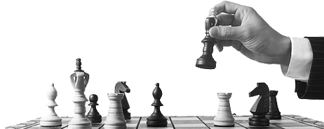

Project summary

In this project, a text (**tournamentinfo.txt**) file was given with chess tournament results where the information has some structure.

Below is an example of the chess tournament table structure. It is a .txt file with **PIPE** Delimited character

```
##  [1] "-----------------------------------------------------------------------------------------"
##  [2] " Pair | Player Name                     |Total|Round|Round|Round|Round|Round|Round|Round| "
##  [3] " Num  | USCF ID / Rtg (Pre->Post)       | Pts |  1  |  2  |  3  |  4  |  5  |  6  |  7  | "
##  [4] "-----------------------------------------------------------------------------------------"
##  [5] "    1 | GARY HUA                        |6.0  |W  39|W  21|W  18|W  14|W   7|D  12|D   4|"
##  [6] "   ON | 15445895 / R: 1794   ->1817     |N:2  |W    |B    |W    |B    |W    |B    |W    |"
##  [7] "-----------------------------------------------------------------------------------------"
##  [8] "    2 | DAKSHESH DARURI                 |6.0  |W  63|W  58|L   4|W  17|W  16|W  20|W   7|"
##  [9] "   MI | 14598900 / R: 1553   ->1663     |N:2  |B    |W    |B    |W    |B    |W    |B    |"
## [10] "-----------------------------------------------------------------------------------------"
## [11] "    3 | ADITYA BAJAJ                    |6.0  |L   8|W  61|W  25|W  21|W  11|W  13|W  12|"
## [12] "   MI | 14959604 / R: 1384   ->1640     |N:2  |W    |B    |W    |B    |W    |B    |W    |"
## [13] "-----------------------------------------------------------------------------------------"
```

My bellow process create a R Markdown file that generates a .CSV file which could for example be imported into a SQL database, with the following information for all of the players: (**Total # of Players are - 64** )

- Player’s Name
- Player’s State
- Player’s Pre-Rating
- Total Number of Points
- Average Pre Chess Rating of Opponents

For the first player, the information would be:

| a | b | c | d | e | f | g |
| --- | --- | --- | --- | --- | --- | --- |
| ID | Name | State | Total Pts | Pre Rating | Post Rating | Opp Avg |
| 1 | GARY HUA | ON | 6 | 1794 | 1817 | 1605 |

1605 was calculated by using the pre-tournament opponents’ ratings of 1436, 1563, 1600, 1610, 1649, 1663, 1716, and dividing by the total number of games played.

The chess rating system (invented by a Minnesota statistician named Arpad Elo) has been used in many other contexts, including assessing relative strength of employment candidates by human resource departments.

Project Steps

~ Connect and load the tournamentinfo.txt

~ Analysis of the data structure

~ Stage and Separate data rows using Regular Expression

~ Extract Data rows using Regular Expression

~ Calculate Mean Ratings

~ Combine Data Frames

~ Export Selected Columns to a .csv Output File

Connect and load the tournamentinfo.txt

```r
url <- "https://raw.githubusercontent.com/kfolsom98/DATA607/master/tournamentinfo.txt"
#url <- "https://raw.githubusercontent.com/mathsanu/CUNY_MSDA/master/DATA607/project1/tournamentinfo.txt"
download_file <- "tournamentinfo.txt" # name of the file on the local machine after download
# the file will be downloaded to the working directory
downloader::download(url, download_file)
# read the file into a vector
conn <- file(download_file, open="r")
tournamentinfo <- readLines(conn, warn = FALSE)
#tournamentinfo
#tournamentinfo[1:13]
close(conn)
```

Back to the Menu<sub><sub><sub><sub><sub><sub><sub>~</sub></sub></sub></sub></sub></sub></sub>

Analysis of the data structure

```r
length(tournamentinfo)
```

```
## [1] 196
```

```r
head(tournamentinfo)
```

```
## [1] "-----------------------------------------------------------------------------------------"
## [2] " Pair | Player Name                     |Total|Round|Round|Round|Round|Round|Round|Round| "
## [3] " Num  | USCF ID / Rtg (Pre->Post)       | Pts |  1  |  2  |  3  |  4  |  5  |  6  |  7  | "
## [4] "-----------------------------------------------------------------------------------------"
## [5] "    1 | GARY HUA                        |6.0  |W  39|W  21|W  18|W  14|W   7|D  12|D   4|"
## [6] "   ON | 15445895 / R: 1794   ->1817     |N:2  |W    |B    |W    |B    |W    |B    |W    |"
```

Back to the Menu<sub><sub><sub><sub><sub><sub><sub>~</sub></sub></sub></sub></sub></sub></sub>

Stage and Separate data rows using Regular Expression

As seen above, we have to remove the header i.e row 1 to row 4.Without removing header and subsequent code will retrieve Player Info and Rating Info.

```r
# Remove lines with "-"
toinfo.stg <- str_replace_all(str_replace_all(tournamentinfo, "->", ">>"), "-{3,}", "")
toinfo.stg <- tournamentinfo[toinfo.stg  != ""]
toinfo.stg<- toinfo.stg[-(1:2)]


# determine the format by looking at the contents of the first field in the record

toinfo.players <- toinfo.stg[str_detect(str_sub(toinfo.stg, 1, 6), "[0-9]")]
toinfo.ratings <- toinfo.stg[str_detect(str_sub(toinfo.stg, 1, 6), "[A-Z]{2,2}")]
```

```r
head(toinfo.players, 5)
```

```
## [1] "    1 | GARY HUA                        |6.0  |W  39|W  21|W  18|W  14|W   7|D  12|D   4|"
## [2] "    2 | DAKSHESH DARURI                 |6.0  |W  63|W  58|L   4|W  17|W  16|W  20|W   7|"
## [3] "    3 | ADITYA BAJAJ                    |6.0  |L   8|W  61|W  25|W  21|W  11|W  13|W  12|"
## [4] "    4 | PATRICK H SCHILLING             |5.5  |W  23|D  28|W   2|W  26|D   5|W  19|D   1|"
## [5] "    5 | HANSHI ZUO                      |5.5  |W  45|W  37|D  12|D  13|D   4|W  14|W  17|"
```

```r
head(toinfo.ratings, 5)
```

```
## [1] "   ON | 15445895 / R: 1794   ->1817     |N:2  |W    |B    |W    |B    |W    |B    |W    |"
## [2] "   MI | 14598900 / R: 1553   ->1663     |N:2  |B    |W    |B    |W    |B    |W    |B    |"
## [3] "   MI | 14959604 / R: 1384   ->1640     |N:2  |W    |B    |W    |B    |W    |B    |W    |"
## [4] "   MI | 12616049 / R: 1716   ->1744     |N:2  |W    |B    |W    |B    |W    |B    |B    |"
## [5] "   MI | 14601533 / R: 1655   ->1690     |N:2  |B    |W    |B    |W    |B    |W    |B    |"
```

Back to the Menu<sub><sub><sub><sub><sub><sub><sub>~</sub></sub></sub></sub></sub></sub></sub>

Extract Data rows using Regular Expression

```r
pairNo <- as.integer(str_extract(toinfo.players, "\\d+"))
Name <- str_trim(str_extract(toinfo.players, "(\\w+\\s){2,3}"))
Region <- str_extract(toinfo.ratings, "\\w+")
Points <- as.numeric(str_extract(toinfo.players, "\\d+\\.\\d+"))
Rating <- as.integer(str_extract(str_extract(toinfo.ratings, "[^\\d]\\d{3,4}[^\\d]"), "\\d+"))
Opponents <- str_extract_all(str_extract_all(toinfo.players, "\\d+\\|"), "\\d+")
Won <- str_count(toinfo.players, "\\Q|W  \\E")
Loose <- str_count(toinfo.players, "\\Q|L  \\E")
Draw <- str_count(toinfo.players, "\\Q|D  \\E")
```

```r
# # of  of Players
length(toinfo.players)
```

```
## [1] 64
```

```r
# # of  of ratings
length(toinfo.ratings)
```

```
## [1] 64
```

Back to the Menu<sub><sub><sub><sub><sub><sub><sub>~</sub></sub></sub></sub></sub></sub></sub>

Calculate Mean Ratings

```r
mRating <- length(toinfo.players)
for (i in 1:length(toinfo.players)) {
  mRating[i] <- round(mean(Rating[as.numeric(unlist(Opponents[pairNo[i]]))]), digits = 0)
}
opData <- data.frame(Name, Region, Points, Rating, mRating, Won, Loose, Draw);
head(opData)
```

```
##                  Name Region Points Rating mRating Won Loose Draw
## 1            GARY HUA     ON    6.0   1794    1605   5     0    2
## 2     DAKSHESH DARURI     MI    6.0   1553    1469   6     1    0
## 3        ADITYA BAJAJ     MI    6.0   1384    1564   6     1    0
## 4 PATRICK H SCHILLING     MI    5.5   1716    1574   4     0    3
## 5          HANSHI ZUO     MI    5.5   1655    1501   4     0    3
## 6         HANSEN SONG     OH    5.0   1686    1519   4     1    2
```

Back to the Menu<sub><sub><sub><sub><sub><sub><sub>~</sub></sub></sub></sub></sub></sub></sub>

Combine Data Frames

```r
# Display All the Pivoted Columns in a Table

colnames(opData) <- c("Player's Name", "Player's State", "Total Number of Points", "Player's Pre-Rating", " Average Pre Chess Rating of Opponents", "Won", "Lost", "Draw")
datatable(opData)
```

|  | Player's Name | Player's State | Total Number of Points | Player's Pre-Rating | Average Pre Chess Rating of Opponents | Won | Lost | Draw |
| --- | --- | --- | --- | --- | --- | --- | --- | --- |
| 1 | GARY HUA | ON | 6 | 1794 | 1605 | 5 | 0 | 2 |
| 2 | DAKSHESH DARURI | MI | 6 | 1553 | 1469 | 6 | 1 | 0 |
| 3 | ADITYA BAJAJ | MI | 6 | 1384 | 1564 | 6 | 1 | 0 |
| 4 | PATRICK H SCHILLING | MI | 5.5 | 1716 | 1574 | 4 | 0 | 3 |
| 5 | HANSHI ZUO | MI | 5.5 | 1655 | 1501 | 4 | 0 | 3 |
| 6 | HANSEN SONG | OH | 5 | 1686 | 1519 | 4 | 1 | 2 |
| 7 | GARY DEE SWATHELL | MI | 5 | 1649 | 1372 | 5 | 2 | 0 |
| 8 | EZEKIEL HOUGHTON | MI | 5 | 1641 | 1468 | 5 | 2 | 0 |
| 9 | STEFANO LEE | ON | 5 | 1411 | 1523 | 5 | 2 | 0 |
| 10 | ANVIT RAO | MI | 5 | 1365 | 1554 | 4 | 1 | 2 |

[output cut: 54 more lines]

Back to the Menu<sub><sub><sub><sub><sub><sub><sub>~</sub></sub></sub></sub></sub></sub></sub>

Export Selected Columns to a .csv Output File

```r
# Select only the specified columns to export

Final.df <- data.frame(Name , Region, Points, Rating, mRating);
colnames(Final.df ) <- c("Player's Name", "Player's State", "Total Number of Points", "Player's Pre-Rating", " Average Pre Chess Rating of Opponents")
head(Final.df)
```

```
##         Player's Name Player's State Total Number of Points
## 1            GARY HUA             ON                    6.0
## 2     DAKSHESH DARURI             MI                    6.0
## 3        ADITYA BAJAJ             MI                    6.0
## 4 PATRICK H SCHILLING             MI                    5.5
## 5          HANSHI ZUO             MI                    5.5
## 6         HANSEN SONG             OH                    5.0
##   Player's Pre-Rating  Average Pre Chess Rating of Opponents
## 1                1794                                   1605
## 2                1553                                   1469
## 3                1384                                   1564
## 4                1716                                   1574
## 5                1655                                   1501
## 6                1686                                   1519
```

#### Export above Data frame to a .csv File

```r
write.csv(Final.df, file = "stgChessInfo.csv")
```

Back to the Menu<sub><sub><sub><sub><sub><sub><sub>~</sub></sub></sub></sub></sub></sub></sub>